Faculty of Economic Sciences

Advanced programming in R - Academic year 2019/2020

10. Web application with Shiny R part 1.

# Widgets in Shiny R

Piotr Ćwiakowski

29 kwiecień, 2021

# 1. Widgets

One of them most important elements of every interface are widgets. With their support user, can input data to the application. Widgets in shiny can be divided into four groups:

- choice lists with closed list of values,
- calendars,
- widgets with open list of values,
- buttons.

## 1.1 Choice lists with closed list of values

Before running examples, please import `stringr` library.

### 1.1.1 Examples

#### checkboxInput

Create a checkbox that can be used to specify logical values. (`TRUE` or `FALSE`).

**Parameters:**

- `inputId` – The input slot that will be used to access the value.
- `label` – Display label for the control, or NULL for no label.
- `value` – Initial value (TRUE or FALSE).
- `width` – The width of the input, e.g. ‘400px’, or ‘100%’

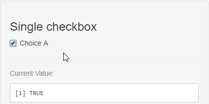

###### ui.R

```r
ui <- fluidPage(
  titlePanel("checkboxInput"),
  sidebarLayout(
    sidebarPanel(
      checkboxInput(
        inputId = "cbx",
        label = "Select/unselect",
        value = TRUE,
        width = "400px"
      )
    ),
    mainPanel(textOutput("txt"))
  )
)
```

###### server.R

```r
library(stringr)

server <- function(input, output, session) {
  output$txt <- renderText({
    str_c("Is it selected?", input$cbx, sep = " ")
  })
}
```

#### checkboxGroupInput

Create a group of checkboxes that can be used to toggle multiple choices independently. The server will receive the input as a character vector of the selected values.

**Parameters:**

- `inputId` – The input slot that will be used to access the value.
- `label` – Display label for the control, or NULL for no label.
- `choices` – List of values to show checkboxes for. If elements of the list are named then that name rather than the value is displayed to the user. If this argument is provided, then choiceNames and choiceValues must not be provided, and vice-versa. The values should be strings; other types (such as logicals and numbers) will be coerced to strings.
- `selected` – The values that should be initially selected, if any.
- `inline` – If TRUE, render the choices inline (i.e. horizontally)
- `width` – The width of the input, e.g. ‘400px’, or ‘100%’; see validateCssUnit()
- `choiceNames`, `choiceValues` – List of names and values, respectively, that are displayed to the user in the app and correspond to the each choice (for this reason, choiceNames and choiceValues must have the same length). If either of these arguments is provided, then the other must be provided and choices must not be provided. The advantage of using both of these over a named list for choices is that choiceNames allows any type of UI object to be passed through (tag objects, icons, HTML code, …), instead of just simple text.

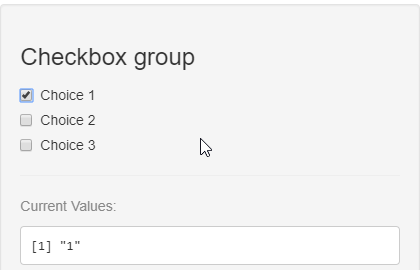

###### ui.R

```r
ui <- fluidPage(
  titlePanel("checkboxGroupInput"),
  sidebarLayout(
    sidebarPanel(
      checkboxGroupInput(
        inputId = "cgi",
        label = "Not excluding choices:",
        selected = "white",
        inline = TRUE,
        choiceNames = c("Blue", "White", "Red"),
        choiceValues = c("blue", "white", "red")
      )
    ),
    mainPanel(textOutput("txt"))
  )
)
```

###### server.R

```r
library(stringr)

server <- function(input, output, session) {
  output$txt <- renderText({
    str_c("Chosen options:", str_c(input$cgi, collapse = ", "), sep = " ")
  })
}
```

#### selectInput

Create a select list that can be used to choose a single or multiple items from a list of values.

**Parametry:**

- `inputId` – The input slot that will be used to access the value.
- `label` – Display label for the control, or NULL for no label.
- `choices` – List of values to select from. If elements of the list are named, then that name — rather than the value — is displayed to the user.
- `selected` – The initially selected value (or multiple values if multiple = TRUE). If not specified then defaults to the first value for single-select lists and no values for multiple select lists.
- `multiple` – Is selection of multiple items allowed?
- `selectize` – Whether to use selectize.js or not.
- `width` – The width of the input, e.g. ‘400px’, or ‘100%’
- `size` – Number of items to show in the selection box; a larger number will result in a taller box. Not compatible with selectize=TRUE. Normally, when multiple=FALSE, a select input will be a drop-down list, but when size is set, it will be a box instead.

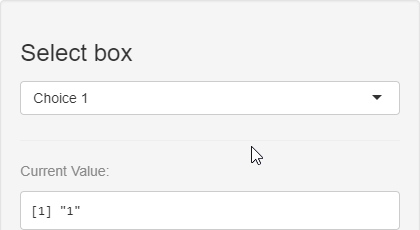

###### ui.R

```r
ui <- fluidPage(
  titlePanel("selectInput"),
  sidebarLayout(
    sidebarPanel(
      selectInput(
        inputId = "sct",
        label = "Letters:",
        choices = letters,
        selected = "",
        multiple = TRUE,
        selectize = FALSE,
        size = 7
      )
    ),
    mainPanel(textOutput("txt"))
  )
)
```

###### server.R

```r
library(stringr)

server <- function(input, output, session) {
  output$txt <- renderText({
    str_c("Selected item(s):", str_c(input$sct, collapse = ", "), sep = " ")
  })
}
```

#### selectizeInput

In the contrary to the function `selectInput` with argument `selectize = TRUE`, this functions allows to cancel selected item even if this is a single choice list. In that case stored value will be `""`.

**Parameters:**

- `inputId` – The input slot that will be used to access the value.
- `...` – Arguments passed to `selectInput`
- `options` – A list of options. See the documentation of selectize.js for possible options.
- `width` – width of the widget

###### ui.R

```r
ui <- fluidPage(
  titlePanel("selectizeInput"),
  sidebarLayout(
    sidebarPanel(
      selectizeInput(
        inputId = "stz",
        label = "Letters:",
        choices = LETTERS,
        selected = "",
        multiple = TRUE
      )
    ),
    mainPanel(textOutput("txt"))
  )
)
```

###### server.R

```r
library(stringr)

server <- function(input, output, session) {
  output$txt <- renderText({
    str_c("Selected items:", str_c(input$stz, collapse = ", "), sep = " ")
  })
}
```

#### radioButtons

Create a set of radio buttons used to select an item from a list.

**Parameters:**

- `inputId` – The input slot that will be used to access the value.
- `label` – Display label for the control, or NULL for no label.
- `choices` – List of values to select from (if elements of the list are named then that name rather than the value is displayed to the user). If this argument is provided, then choiceNames and choiceValues must not be provided, and vice-versa. The values should be strings; other types (such as logicals and numbers) will be coerced to strings.
- `selected` – The initially selected value (if not specified then defaults to the first value)
- `inline` – If TRUE, render the choices inline (i.e. horizontally)
- `choiceNames`, `choiceValues` – List of names and values, respectively, that are displayed to the user in the app and correspond to the each choice (for this reason, choiceNames and choiceValues must have the same length). If either of these arguments is provided, then the other must be provided and choices must not be provided. The advantage of using both of these over a named list for choices is that choiceNames allows any type of UI object to be passed through (tag objects, icons, HTML code, …), instead of just simple text.

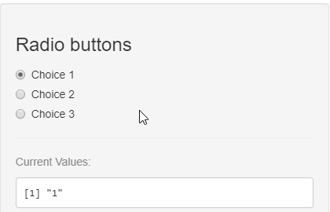

###### ui.R

```r
ui <- fluidPage(
  titlePanel("radioButtons"),
  sidebarLayout(
    sidebarPanel(
      radioButtons(
        inputId = "rdb",
        label = "Excluding choices:",
        selected = "foot",
        choiceNames = list(icon("plane"), icon("car"), icon("male")),
        choiceValues = list("plane", "car", "foot"),
        inline = FALSE
      )
    ),
    mainPanel(textOutput("txt"))
  )
)
```

###### server.R

```r
library(stringr)

server <- function(input, output, session) {
  output$txt <- renderText({
    str_c("Selected item:", input$rdb, sep = " ")
  })
}
```

### 1.1.2 Exercises

Copy necessary code to separated scripts in R (`ui.R`, `server.R` or `app.R`) and follow the instructions:

1. In call of function `checkboxGroupInput`:
   1. change parameter `label` to `"Iris Species:"`,
   2. set value of `choices` to unique list of column `Species` from data.frame `iris`,
   3. change also parameter `inline` to `TRUE` and see what will be impact for app,
   4. do not set any values for parameters `choiceNames` and `choiceValues` and run app. Study differencess in appearence and behavior of the widget.
2. In call of function `selectInput`:
   1. set parameter `multiple` to `FALSE`, and `width` to `"200px"`,
   2. comment parameters `size` and `selected`,
   3. run app, choose item(s), and try to cancel choice. Close app,
   4. then set parameter `choices` to value `c("Choose..." = "", letters)`,
   5. run app, choose item(s) and again try to cancel choice - then close app and
   6. change parameter `selectize` to `TRUE`. run app choose item(s) from the list, then cancel it. Again close app and set parameter `choices` to value `letters`.
   7. run app, choose item(s) and again try to cancel your choice. Then, comment parameter `selectize` and change widget function to `selectizeInput`.
   8. run app and powtórz schemat działania. Discribe differences in behaviour of tested widgets.

## 1.2 Calendars

### 1.2.1 Examples

#### dateInput

Creates a text input which, when clicked on, brings up a calendar that the user can click on to select dates.

**Parameters:**

- `inputId` – The input slot that will be used to access the value.
- `label` – Display label for the control, or NULL for no label.
- `value` – The starting date. Either a Date object, or a string in yyyy-mm-dd format. If NULL (the default), will use the current date in the client’s time zone.
- `min` – The minimum allowed date. Either a Date object, or a string in yyyy-mm-dd format.
- `max` – The maximum allowed date. Either a Date object, or a string in yyyy-mm-dd format.
- `format` – The format of the date to display in the browser. Defaults to “yyyy-mm-dd”.
- `startview` – The date range shown when the input object is first clicked. Can be “month” (the default), “year”, or “decade”.
- `weekstart` – Which day is the start of the week. Should be an integer from 0 (Sunday) to 6 (Saturday).
- `language` – The language used for month and day names. Default is “en”. See Docs for further information.
- `width` – the width of the input, e.g. ‘400px’, or ‘100%’;
- `autoclose` – Whether or not to close the datepicker immediately when a date is selected.
- `datesdisabled` – Which dates should be disabled. Either a Date object, or a string in yyyy-mm-dd format.
- `daysofweekdisabled` – Days of the week that should be disabled. Should be a integer vector with values from 0 (Sunday) to 6 (Saturday).

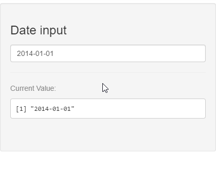

###### ui.R

```r
ui <- fluidPage(
  titlePanel("dateInput"),
  sidebarLayout(
    sidebarPanel(
      dateInput(
        inputId = "dti",
        label = "Date from calendar:",
        value = "1986-10-07",
        min = "1980-01-01",
        max = "2020-01-01",
        format = "mm-dd-yyyy",
        startview = "year",
        weekstart = 1,
        language = "pl",
        width = "200px",
        autoclose = FALSE
      )
    ),
    mainPanel(textOutput("txt"))
  )
)
```

###### server.R

```r
server <- function(input, output, session) {
  output$txt <- renderText({
    str_c("Date:", input$dti, sep = " ")
  })
}
```

#### dateRangeInput

Creates a pair of text inputs which, when clicked on, bring up calendars that the user can click on to select dates.

**Parameters:**

- `inputId` – The input slot that will be used to access the value.
- `label` – Display label for the control, or NULL for no label.
- `start` – The initial start date. Either a Date object, or a string in yyyy-mm-dd format. If NULL (the default), will use the current date in the client’s time zone.
- `end` – The initial end date. Either a Date object, or a string in yyyy-mm-dd format. If NULL (the default), will use the current date in the client’s time zone.
- `min` – The minimum allowed date. Either a Date object, or a string in yyyy-mm-dd format.
- `max` – The maximum allowed date. Either a Date object, or a string in yyyy-mm-dd format.
- `format` – The format of the date to display in the browser. Defaults to “yyyy-mm-dd”.
- `startview` – The date range shown when the input object is first clicked. Can be “month” (the default), “year”, or “decade”.
- `weekstart` – Which day is the start of the week. Should be an integer from 0 (Sunday) to 6 (Saturday).
- `language` – The language used for month and day names. Default is “en”.
- `separator` – String to display between the start and end input boxes.
- `width` – The width of the input, e.g. ‘400px’, or ‘100%’
- `autoclose` – Whether or not to close the datepicker immediately when a date is selected.

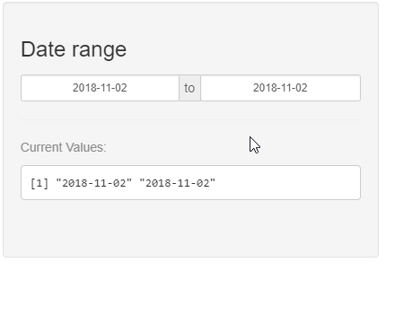

###### ui.R

```r
ui <- fluidPage(
  titlePanel("dateRangeInput"),
  sidebarLayout(
    sidebarPanel(
      dateRangeInput(
        inputId = "dtr",
        label = "Date interval:",
        start = "2018-07-01",
        end = "2018-08-31",
        min = "2018-07-01",
        max = "2018-08-31",
        format = "yyyy-mm-dd",
        startview = "decade",
        weekstart = 0,
        language = "pl",
        separator = "do",
        width = "300px",
        autoclose = FALSE
      )
    ),
    mainPanel(textOutput("txt"))
  )
)
```

###### server.R

```r
server <- function(input, output, session) {
  output$txt <- renderText({
    str_c("Date interval from",
          str_c(input$dtr[1], "to", input$dtr[2], sep = " "),
          sep = " ")
  })
}
```

## 1.3 Widgets with open list of values

### 1.3.1 Examples

#### sliderInput

Constructs a slider widget to select a numeric value from a range.

**Parameters:**

- `inputId` – The input slot that will be used to access the value.
- `label` – Display label for the control, or NULL for no label.
- `min` – The minimum value (inclusive) that can be selected.
- `max` – The maximum value (inclusive) that can be selected.
- `value` – The initial value of the slider. A numeric vector of length one will create a regular slider; a numeric vector of length two will create a double-ended range slider. A warning will be issued if the value doesn’t fit between min and max.
- `step` – Specifies the interval between each selectable value on the slider (if NULL, a heuristic is used to determine the step size). If the values are dates, step is in days; if the values are times (POSIXt), step is in seconds.
- `round` – TRUE to round all values to the nearest integer; FALSE if no rounding is desired; or an integer to round to that number of digits (for example, 1 will round to the nearest 10, and -2 will round to the nearest .01). Any rounding will be applied after snapping to the nearest step.
- `format` – Depracrated
- `locale` – Depracrated
- `ticks` – FALSE to hide tick marks, TRUE to show them according to some simple heuristics.
- `animate` – TRUE to show simple animation controls with default settings; FALSE not to; or a custom settings list, such as those created using animationOptions().
- `width` – The width of the input, e.g. ‘400px’, or ‘100%’; see validateCssUnit().
- `sep` – Separator between thousands places in numbers.
- `pre` – A prefix string to put in front of the value.
- `post` – A suffix string to put after the value.
- `timeFormat` – Only used if the values are Date or POSIXt objects. A time format string, to be passed to the Javascript strftime library.
- `timezone` – nly used if the values are POSIXt objects. A string specifying the time zone offset for the displayed times, in the format “+HHMM” or “-HHMM”. If NULL (the default), times will be displayed in the browser’s time zone. The value “+0000” will result in UTC time.
- `dragRange` –  
  This option is used only if it is a range slider (with two values). If TRUE (the default), the range can be dragged. In other words, the min and max can be dragged together. If FALSE, the range cannot be dragged.

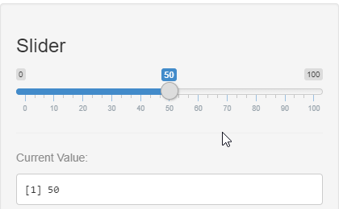

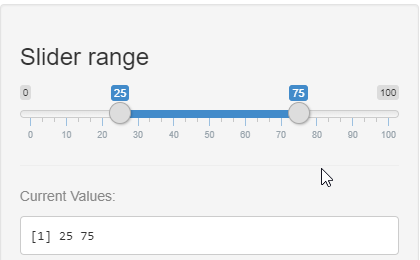

Through `animationOptions` one can set some animation parameters.

- `interval` – interval. The interval, in milliseconds, between each animation step.
- `loop` –  
  Specifies the appearance of the play button. Valid values are a one-element character vector (for a simple text label), an HTML tag or list of tags (using tag() and friends), or raw HTML (using HTML()).
- `playButton` –  
  Specifies the appearance of the play button. Valid values are a one-element character vector (for a simple text label), an HTML tag or list of tags (using tag() and friends), or raw HTML (using HTML()).
- `pauseButton` – Similar to playButton, but for the pause button.

###### ui.R

```r
ui <- fluidPage(
  titlePanel("sliderInput"),
  sidebarLayout(
    sidebarPanel(
      sliderInput(
        inputId = "slr",
        label = "Numeric interval:",
        min = 990,
        max = 1010,
        value = c(996, 998),
        step = 2,
        round = TRUE,
        ticks = FALSE,
        animate = animationOptions(interval = 2000, loop = TRUE,
                                   playButton = "Start", pauseButton = "Pauza"),
        width = "300px",
        sep = ".",
        pre = "<",
        post = "$",
        dragRange = FALSE
      )
    ),
    mainPanel(textOutput("txt"))
  )
)
```

###### server.R

```r
server <- function(input, output, session) {
  output$txt <- renderText({
    str_c("Numeric interval from:",
          str_c(input$slr[1], "to:", input$slr[2], sep = " "),
          sep = " ")
  })
}
```

#### textInput

Create an input control for entry of unstructured text values.

**Parametry:**

- `inputId` – The input slot that will be used to access the value.
- `label` – Display label for the control, or NULL for no label.
- `value` – Initial value.
- `width` – The width of the input, e.g. ‘400px’, or ‘100%’
- `placeholder` – A character string giving the user a hint as to what can be entered into the control.

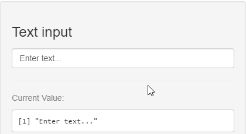

###### ui.R

```r
ui <- fluidPage(
  titlePanel("textInput"),
  sidebarLayout(
    sidebarPanel(
      textInput(
        inputId = "txt",
        label = "Input text:",
        value = "",
        width = "300px",
        placeholder = "Maybe a poem?..."
      )
    ),
    mainPanel(textOutput("txt"))
  )
)
```

###### server.R

```r
server <- function(input, output, session) {
  output$txt <- renderText({
    str_c("Input text:", input$txt, sep = " ")
  })
}
```

#### numericInput

Create an input control for entry of numeric values.

**Parameters:**

- `inputId` – The input slot that will be used to access the value.
- `label` – Display label for the control, or NULL for no label.
- `value` – Initial value.
- `min` – Minimum allowed value
- `max` – Maxmimum allowed value
- `step` – Interval to use when stepping between min and max
- `width` – The width of the input

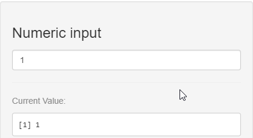

###### ui.R

```r
ui <- fluidPage(
  titlePanel("numericInput"),
  sidebarLayout(
    sidebarPanel(
      numericInput(
        inputId = "num",
        label = "Enter a number:",
        value = 0,
        min = -3,
        max = 9,
        step = 3,
        width = "300px"
      )
    ),
    mainPanel(textOutput("txt"))
  )
)
```

###### server.R

```r
server <- function(input, output, session) {
  output$txt <- renderText({
    str_c("Input number is:", input$num, sep = " ")
  })
}
```

#### fileInput

Create a file upload control that can be used to upload one or more files.

**Parameters:**

- `inputId` – The input slot that will be used to access the value.
- `label` – Display label for the control, or NULL for no label.
- `multiple` – Whether the user should be allowed to select and upload multiple files at once. Does not work on older browsers, including Internet Explorer 9 and earlier.
- `accept` – A character vector of MIME types; gives the browser a hint of what kind of files the server is expecting.
- `width` – The width of the input, e.g. ‘400px’, or ‘100%’
- `buttonLabel` – The label used on the button. Can be text or an HTML tag object.
- `placeholder` – The text to show before a file has been uploaded

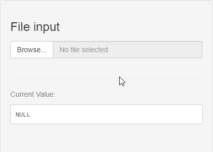

###### ui.R

```r
ui <- fluidPage(
  titlePanel("fileInput"),
  sidebarLayout(
    sidebarPanel(
      fileInput(
        inputId = "fil",
        label = "Choose file from disk:",
        multiple = TRUE,
        accept = c(".csv", ".txt"),
        width = "300px",
        buttonLabel = icon("folder"),
        placeholder = "Search..."
      )
    ),
    mainPanel(tableOutput("tbl"))
  )
)
```

###### server.R

```r
server <- function(input, output, session) {
  output$tbl <- renderTable({
    if (is.null(input$fil)) {
      return(NULL)
    }

    vec <- unlist(input$fil)

    tibble(key = names(vec), value = vec)
  })
}
```

## 1.4 Buttons

### 1.4.1 Examples

#### actionButton

Creates an action button or link whose value is initially zero, and increments by one each time it is pressed.

**Parameters:**

- `inputId` – The input slot that will be used to access the value.
- `label` – The contents of the button or link–usually a text label, but you could also use any other HTML, like an image.
- `icon` – An optional icon() to appear on the button.
- `width` – The width of the input, e.g. ‘400px’, or ‘100%’; see validateCssUnit().
- `...` – Named attributes to be applied to the button or link.

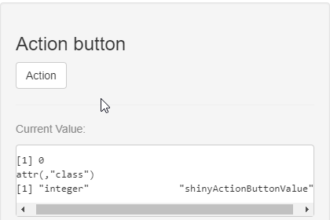

###### ui.R

```r
ui <- fluidPage(
  titlePanel("actionButton"),
  sidebarLayout(
    sidebarPanel(
      actionButton(
        inputId = "btn",
        label = "1",
        icon = icon("plus"),
        width = "400px",
        style = "color: #ffffff; background-color: #6d1f6b;
        border-color: #000000",
        disabled = ""
      )
    ),
  mainPanel(textOutput("txt")))
)
```

###### server.R

```r
server <- function(input, output, session) {
  output$txt <- renderText({
    str_c("Button was clicked:", input$btn, sep = " ", 'times.')
  })
}
```

#### actionLink

Object works exactly the same as `actionButton`, althouh it looks like hyperlink

**Parameters:**

- `inputId` – The input slot that will be used to access the value.
- `label` – The contents of the button or link–usually a text label, but you could also use any other HTML, like an image.
- `icon` – An optional icon() to appear on the button.
- `width` – The width of the input, e.g. ‘400px’, or ‘100%’; see validateCssUnit().
- `...` – Named attributes to be applied to the button or link.a

###### ui.R

```r
ui <- fluidPage(
  titlePanel("actionLink"),
  sidebarLayout(
    sidebarPanel(
      actionLink(
        inputId = "lnk",
        label = "1",
        icon = icon("plus"),
        width = "400px",
        style = "color: green"
      )
    ),
    mainPanel(
      textOutput("txt")
    )
  )
)
```

###### server.R

```r
server <- function(input, output, session) {
  output$txt <- renderText({
    str_c("Link was pressed:", input$lnk, sep = " ", 'times.')
  })
}
```

#### submitButton

**Parametry:**

- `text` – Button caption,
- `icon` – Optional icon() to appear on the butto,
- `width` – The width of the button, e.g. ‘400px’, or ‘100%’.

###### ui.R

```r
ui <- fluidPage(
  titlePanel("submitButton"),
  sidebarLayout(
    sidebarPanel(
      selectInput(
        inputId = "let",
        label = "Letters:",
        choices = letters
      ),
      checkboxInput(
        inputId = "big",
        label = "Show capital letters"
      ),
      numericInput(
        inputId = "mul",
        label = "Multiply by:",
        value = 1,
        min = 1,
        max = 3,
        step = 1
      ),
      submitButton(
        text = "Compute",
        icon = icon("calculator"),
        width = "100px"
      )
    ),
    mainPanel(
      textOutput("txt")
    )
  )
)
```

###### server.R

```r
server <- function(input, output, session) {
  selected <- reactive({
    multiplied <- input$let %>%
      rep(input$mul) %>%
      str_c(collapse = "")

    if (input$big) {
      multiplied %>%
        str_to_upper()
    } else {
      multiplied
    }
  })

  output$txt <- renderText({
    str_c("Current config:", selected(), sep = " ")
  })
}
```

### 1.4.2 Exercises

Copy necessary code to separated scripts in R (`ui.R`, `server.R` or `app.R`) and follow the instructions:

1. In call of function `actionButton`:
   1. change colors in argument `style`,
   2. try use color names in you native language (e. g. `red`, `green`, `blue`),
   3. temporarly comment parameter `disabled`,
   4. change parameter `label` to default text and
   5. parameter `icon` to `"heart"`,
   6. run app. Observe counter while clicking in button.